# DV_Assignment2

Ruoxin WANG

2023-11-14

# Assignment 2

## Description

Please complete the codes such that they can get the same outputs. Submit the .html and .rmd documents to iSpace.

### 1. Prepare the data and use the pie chart to show the proportion of each type of pets.

Hint: scale_fill_brewer() may help. Notice the color mapping.

```r
# Define the dataframe named 'plotdata'.
# Write your code here.
pet <- c("Dog", "Cat", "Psyduck", "Fragrant pig", "Lizard")
num <- c(1600, 2100, 900, 600, 450)

plotdata <- data.frame(pet = pet, num = num)
plotdata
```

```
##            pet  num
## 1          Dog 1600
## 2          Cat 2100
## 3      Psyduck  900
## 4 Fragrant pig  600
## 5       Lizard  450
```

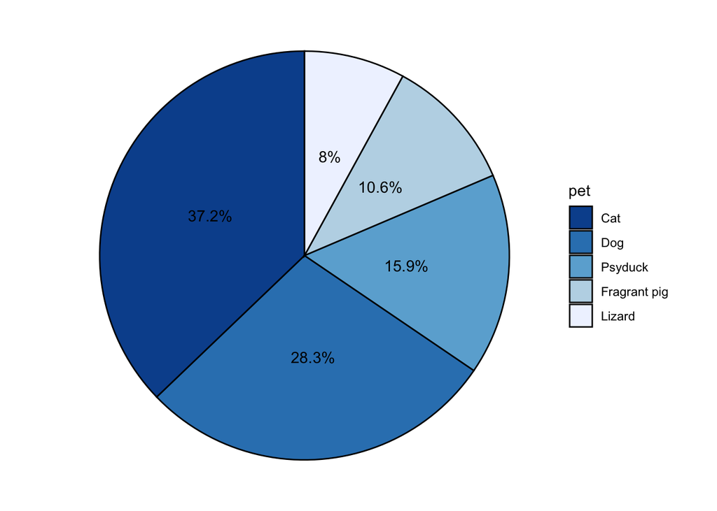

```r
library(ggplot2)
plotdata$pet <- reorder(plotdata$pet, -plotdata$num)
plotdata$percentage <- plotdata$num / sum(plotdata$num) * 100

pie_chart <- ggplot(plotdata, aes(x = "", y = num, fill = pet)) +
  geom_bar(stat = "identity", width = 1, color = "black") +
  coord_polar("y") +
  scale_fill_brewer(palette = "Blues", direction = -1) +
  theme_void() +
  geom_text(aes(label = paste0(round(percentage, 1), "%")), position = position_stack(vjust = 0.5))
print(pie_chart)
```

### 2. Use the dataset CPS85 from the package mosaicData. Please count the number of females and males in each sector.

Hint: You can copy the command View(CPS85) in the console to view the tabular data of CPS85.

```r
# Loading data
library(mosaicData)
data(CPS85, package = "mosaicData")

# Count the number of females and males in each sector
sector_gender_count <- table(CPS85$sector, CPS85$sex)

# Convert the table to a data frame
sector_gender_count_df <- as.data.frame(sector_gender_count)

# Rename the columns
names(sector_gender_count_df) <- c("Sector", "Sex", "Count")

# Exclude rows where Count is 0
sector_gender_count_df <- sector_gender_count_df[sector_gender_count_df$Count != 0, ]

# Order the data frame by the "Sector" column
sector_gender_count_df <- sector_gender_count_df[order(sector_gender_count_df$Sector), ]

# Print the result
print(sector_gender_count_df)
```

```
##      Sector Sex Count
## 1  clerical   F    76
## 9  clerical   M    21
## 10    const   M    20
## 3     manag   F    21
## 11    manag   M    34
## 4     manuf   F    24
## 12    manuf   M    44
## 5     other   F     6
## 13    other   M    62
## 6      prof   F    52
## 14     prof   M    53
## 7     sales   F    17
## 15    sales   M    21
## 8   service   F    49
## 16  service   M    34
```

```r
library(mosaicData)

data(CPS85, package = "mosaicData")

sector_gender_count <- with(CPS85, table(sector, sex))
sector_gender_count_df <- as.data.frame.table(sector_gender_count)
names(sector_gender_count_df) <- c("sector", "sex", "n")

print(sector_gender_count_df)
```

```
##      sector sex  n
## 1  clerical   F 76
## 2     const   F  0
## 3     manag   F 21
## 4     manuf   F 24
## 5     other   F  6
## 6      prof   F 52
## 7     sales   F 17
## 8   service   F 49
## 9  clerical   M 21
## 10    const   M 20
## 11    manag   M 34
## 12    manuf   M 44
## 13    other   M 62
## 14     prof   M 53
## 15    sales   M 21
## 16  service   M 34
```

Construct a stacked bar chart to show the number of females and males in each sectors. Hint: geom_text() may help you show the numbers in the bars. The two color values #C73C68 and B6C468 can help.

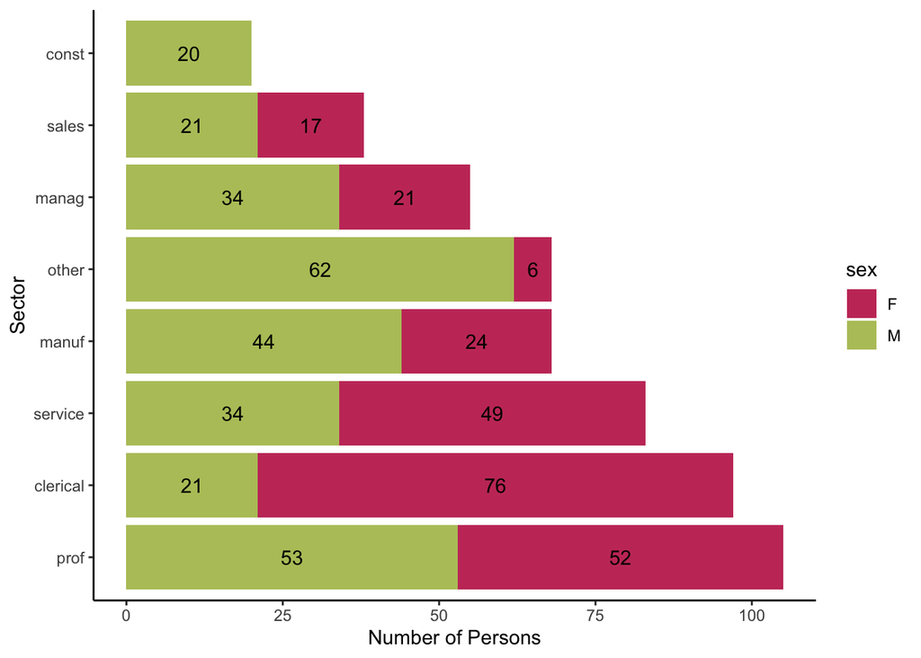

```r
library(ggplot2)
library(tidyr)

sector_gender_count_df <- as.data.frame.matrix(table(CPS85$sector, CPS85$sex))
sector_gender_count_df$sector <- rownames(sector_gender_count_df)
rownames(sector_gender_count_df) <- NULL

sector_gender_count_df <- gather(sector_gender_count_df, key = "sex", value = "count", -sector)

ggplot(sector_gender_count_df,
       aes(x = reorder(sector, -count),
           y = count,
           fill = sex)) +
  geom_bar(stat = "identity") +
  geom_text(aes(label = ifelse(count != 0, as.character(count), "")), position = position_stack(vjust = 0.5)) +
  scale_fill_manual(values = c("#C73C68", "#B6C468")) +
  labs(x = 'Sector', y = "Number of Persons") +
  theme_classic() +
  coord_flip()
```

Hint: geom_smooth() may help you to construct the linear regression line. You can specify the points with size = 1, alpha = 0.4, the fitting line with size = 0.5, color = “tomato”.

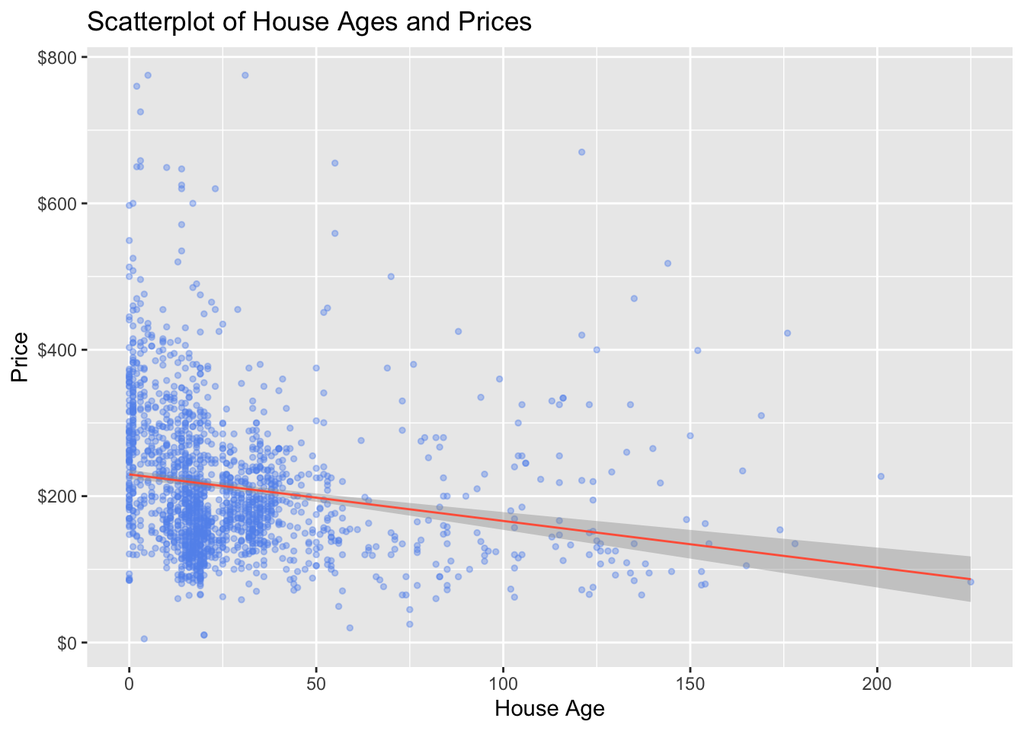

```r
library(mosaicData)
library(ggplot2)

# Load the SaratogaHouses dataset
data(SaratogaHouses)

# Create a scatterplot with quadratic line of best fit
# Create a scatterplot with linear line of best fit
ggplot(SaratogaHouses, aes(x = age, y = price)) +
  geom_point(size = 1, alpha = 0.4,color = "cornflowerblue") +
  geom_smooth(method = "lm", formula = y ~ x,
              size = 0.5, color = "tomato") +
  scale_y_continuous(labels = scales::dollar_format(scale = 0.001)) +
  labs(title = "Scatterplot of House Ages and Prices",
       x = "House Age",
       y = "Price")
```

### 4. Based on the dataset SaratogaHouses from package mosaicData, please draw the boxplot for the house price by number of rooms.

Hint: Transparency of boxplot is specified as alpha = 0.5.

```
## Notch went outside hinges
## ℹ Do you want `notch = FALSE`?
```

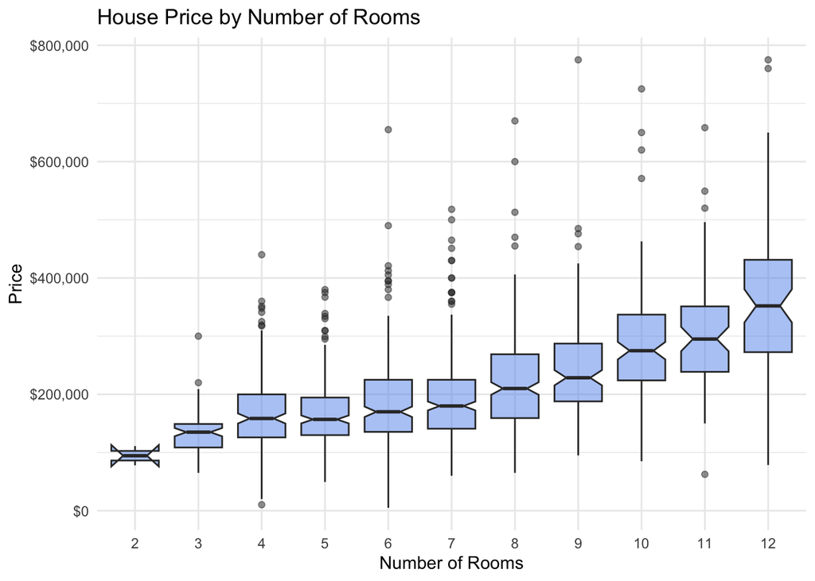

```r
# Plotting a boxplot for the house price by number of rooms
# Write your code here
library(mosaicData)
data(SaratogaHouses, package = "mosaicData")

ggplot(SaratogaHouses, aes(x = factor(rooms), y = price)) +
  geom_boxplot(notch = TRUE,
               fill = "cornflowerblue",
               alpha = .5) +
  scale_y_continuous(labels = scales::dollar_format()) +
  labs(title = "House Price by Number of Rooms",
       x = "Number of Rooms", y = "Price") +
  theme_minimal()
```

### 5. Please plot the Cleveland dot chart for the percentage of receipts in GDP by country. The datasset newgdp from the package CGPfunctions records current receipts of fifteen national governments as a percentage of gross domestic product. You can read more detail by running the code ??newgdp in the console.

1. Selecting all the data in year 1979 and mutate the GDP into percentage.
2. Plot the Cleveland dot chart for GDP percentage by country. Hint: Please install the package CGPfunctions if you haven’t installed. (No need to write the install code in the R code chunk below.) The range of x is (0.2, 0.6).

```r
# Loading data
library(CGPfunctions)
library(dplyr)
```

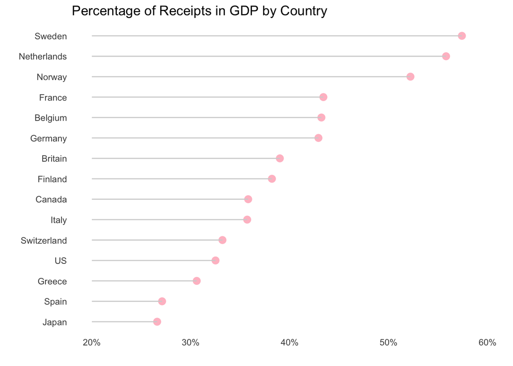

```r
data(newgdp, package = "CGPfunctions")

gdp_1979 <- newgdp %>%
  filter(Year == "Year1979") %>%
  mutate(GDP_Percentage = GDP / 100)
ggplot(gdp_1979, aes(x = GDP_Percentage, y = reorder(Country, GDP_Percentage))) +
  geom_point(color = "pink", size = 3) +
  geom_segment(aes(x = 0.2, xend = GDP_Percentage, yend = Country), color = "lightgrey") +
  labs(title = "Percentage of Receipts in GDP by Country",
       x = "",
       y = "") +
  theme_minimal()+
  theme(panel.grid.major = element_blank(),
        panel.grid.minor = element_blank()) +
  scale_x_continuous(labels = scales::percent, limits = c(0.2, 0.6))
```